# Chicago Bulls Player Recommendation

R.Riddell

26/04/2021

# Introduction

## Background

Basketball is a team sport composed of 5 players per team and was invented around 1891 by James Naismith<sup>(1)</sup>. The game has evolved significantly since then and is now a very popular and lucrative sport internationally. Both players and organisations are able to earn a significant amount of money through sponsorship and media rights<sup>(2)</sup>. To even the financial playing field the modern salary cap was introduced in the 1984-85 season with a $3,600,00 cap. The salary system has grown into a very complex and regulated system that ensures organisations are not able to spend any money they want on players. The NBA salary system is described as a soft cap due to a system of salary cap exceptions and is based off team’s basketball related income. Due to the NBA operating a soft cap it means there can be some range in what salary can be committed to players. Organisations needs to very strategic in the way they structure player contract in order to maximise the money they spend<sup>(3).</sup>

## Aim

The aim of this report is to flag and identify players that will enhance the probability of the Chicago Bulls winning more games than last season.

## Justification

The reason this report is necessary is shown by the discrepancy between what can be spent on players and what the Chicago Bulls can spend on players. This discrepancy highlights that the Chicago Bulls are not able to just recruit any player and instead must be strategic to ensure they buy players that will have a positive influence on winning for their team.

# Wrangling data

The descriptions and information about the data used in this report can be found at [Data Descriptions](https://github.com/RobertRiddell/Final-Project_10157/tree/main/data-descriptions).

## Player Data

The next issue noted was some players had different positions listed, such as Thon Maker who was listed as a PF for Detroit and a Center for Milwaukee. It was decided that the player would be assigned the position they played the most games at. To do this the number of games was totalled for all players and a new position list was tabulated to overwrite the old positions. This function reassigned the players position on all observations to the position they played most during the season.

These players also had a secondary issue where they had different teams listed due to being traded. This issue was solved using the same method as the positions, where the player was assigned the team they played the most number of games from. The player data was then grouped under each name, so each player only had one observation in the dataset.

After grouping the data together there was some calculation errors discovered in some of the field goal percentage statistics. These issues arose as some filed goal values presented as NA and some attempt values were 0 so after the field goal calculation were completed the resultant figure was invalid. The second issue occurred through a zero-division error as there was not attempted shots so therefore the division resulted in an NA instead of a zero. During the recalculation the effective field goal statistics was also included in the data, this statistic takes into account the extra worth of a 3 point percentage. The effective field goal is calculated by using the formula $(FG + 0.5 * 3P) / FGA$<sup>(4)</sup>.

## Team Data

The team data was sourced from three different sources, two differnet set of statistics and another seperate file that contained team payroll information. The statistical information was for each team and collected form the 2018/19 season. The two sets of team statistics were combined with the team based statistics such as pace and offensice rating removed as they were adjudged to not be applicable for player selection. The payroll data was then added to the team based data leaving the data with 33 variables and 30 observations.

# Exploratory analysis

## Distribution

Table 1.

| Statistic | Correlation |
| --- | --- |
| f_tr | 0.02 |
| pf | -0.16 |
| blk | 0.44 |
| trb | 0.53 |
| drb | 0.57 |
| ft_percent | 0.16 |
| fta | 0.06 |
| pts | 0.66 |

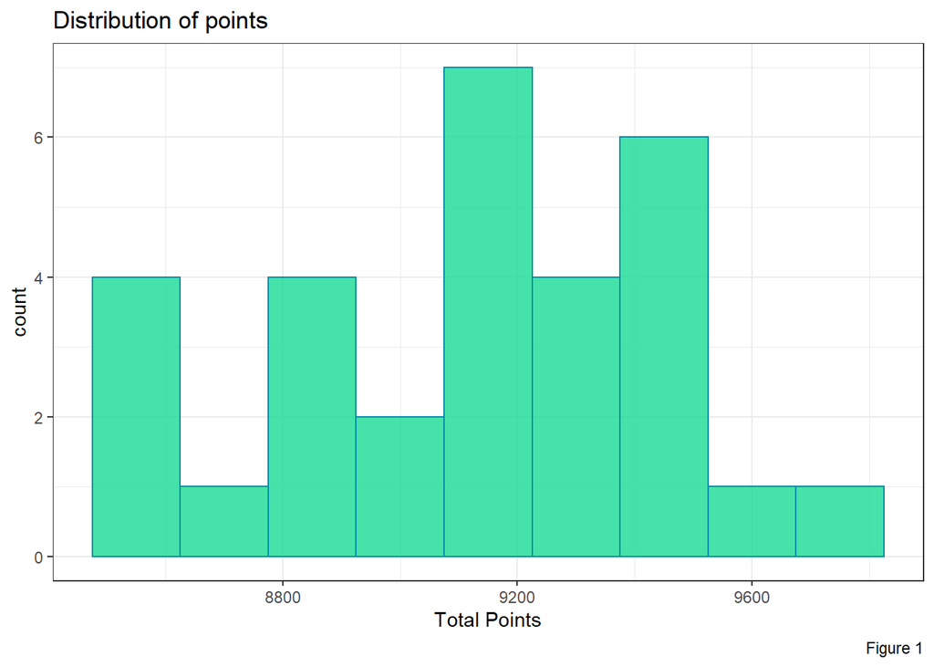

## Relationships

In Figure 2 the relationship between points and winning games has been presented to reinforce the decision that points will be the best indication for games won. Therefore, points will be targeted as the response variable and the other variables will be used to predict it. To standardise the variables all have been converted to per game amounts as opposed to season total amounts.

```
## [1] 0.6606001
```

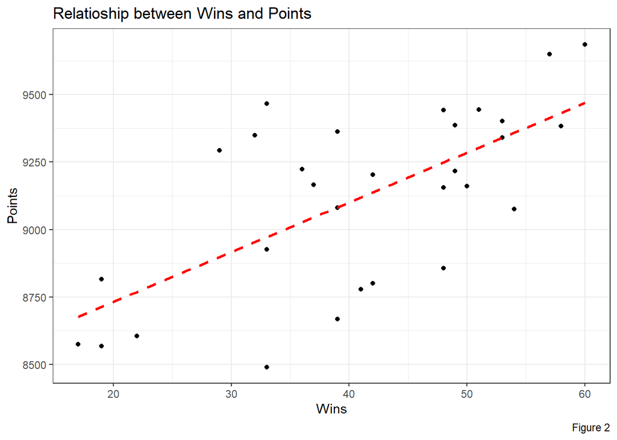

All explanatory variables were assessed visually for their relationship with points and the correlation coefficient was calculated. Through the iterative process of modelling some variables were also removed at this stage due to multicollinearity, a poor linear relationship in the model or a slope confidence interval that straddled zero.

These variables were removed due to a low correlation coefficient of between -0.2 to 0.2:

- 2pa
- mp
- tov
- pf
- ft_percent
- stl
- orb

These variables were removed due to a multicollinearity:

- e_fg_percent
- ft_fga
- fg
- x3p
- x3p_ar
- ft
- fta
- drb
- fg_percent
- x2p_percent
- x3p_percent

These variables were removed due to a poor linear relationship in the model:

- blk

These variables were removed due to an unreliable confidence interval on their slope prediction:

- x3pa
- x2p
- trb
- ast

## Justification

As points has a reasonably normal distribution and a correlation coefficient of 0.66 it is believed that it will provide the predictor for overall games win. It is possible that another statistic that has a better distribution would model better in the data and be more predictable but as the overall goal is too increase wins it is important that the statistic chosen has strong relationship to winning

# Data modelling and results

## Modelling

Through the previous cleaning and exploration of the data the best explanatory variables have been included in the multiple linear regression model. These variables include F-tr,ts_percent and fga. The relevant assumptions have been conducted on the data to ensure all variables meet the requirement of a multiple linear regression model.

## Assumptions

Continuous Variables

- The response variables in points are a continuous variable and all explanatory variables are also continuous.

Linear relationship

- There is an obvious linear relationship between all explanatory variables and points. This has been confirmed used the car package and avPlots function.

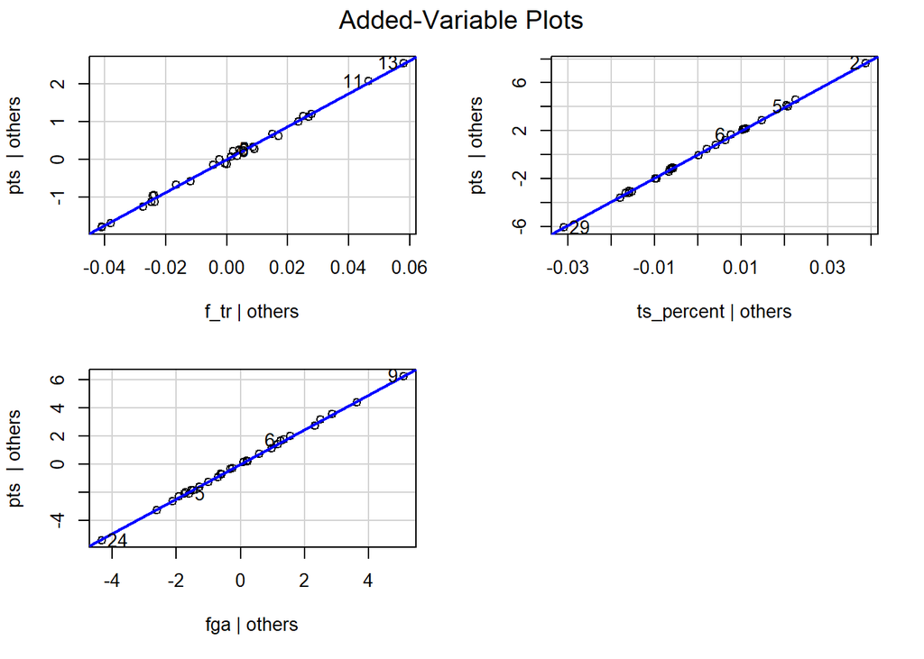

Outliers

- The outlier plot in Figure 3 shows no obvious outliers.

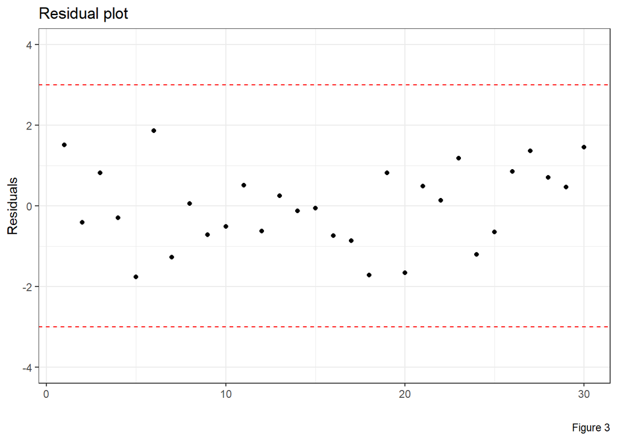

Independence

- Using the car package and the durbinWatsonTest package a Durbin Watson statistic of 2.28 is returned which indicates a normal range and shows the model is independent.

Normally distributed

- To assess the distribution of the model the normality of residuals can be viewed. By looking at a histogram of the residuals and a qqplot the residuals appear normal.

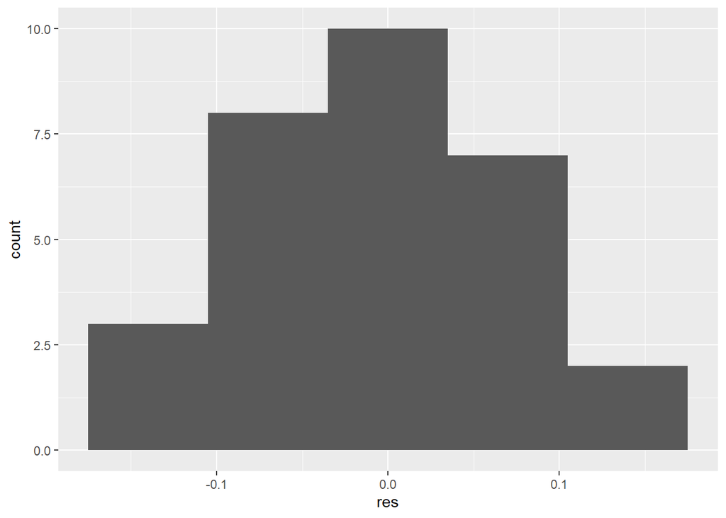

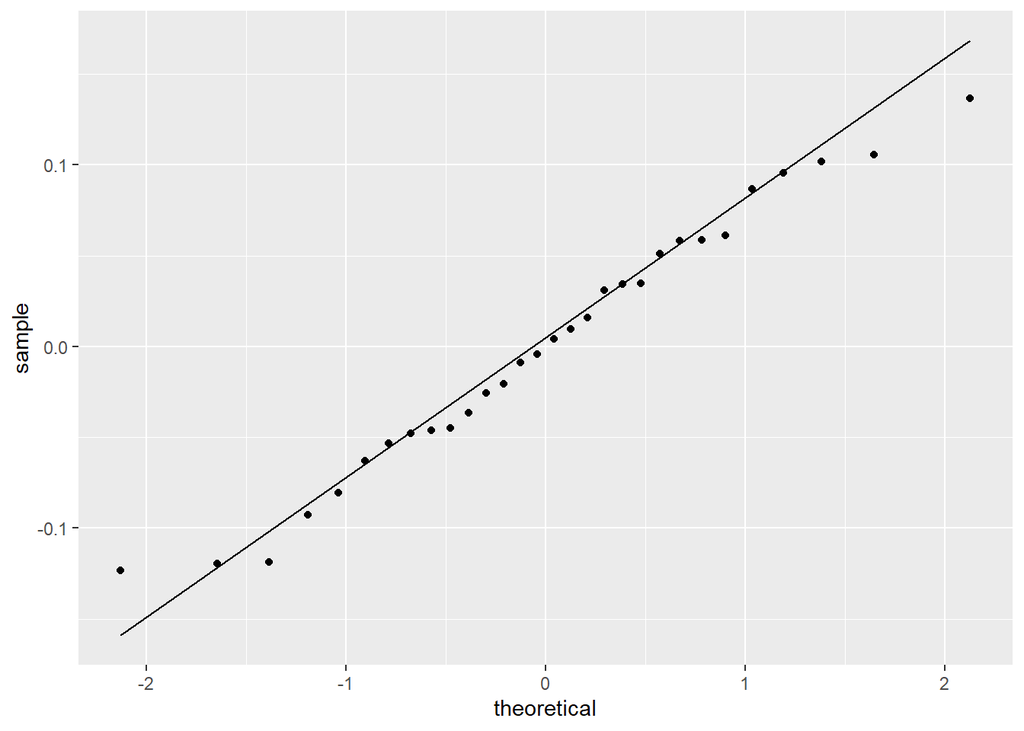

## Model output

# Player recommendation

In order to evaluate and understand players their expected point performance needs to be assessed by the constructed model. A factor that will affect a player overall expected performance is the amount of opportunity they have been given. For instance, a player that has played many more minutes should therefore have a higher number of statistics. In an attempt to mitigate this issue all players statistics can be normalised based on the average amount of minutes per game. This assumption will transform player statistics to what they would be if all players played the same minutes, obviously this assumption may not hold true based on many factors, but it is better to assess players on a more even playing field than let past opportunity be an overwhelming factor that determines future performance.

## Value for money

Table 2: Salary and Expected Points Ranks are grouped by position

| Player Name | Age | Position | Minutes Played | salary | Expected Points | Salary Rank | Expected points rank |
| --- | --- | --- | --- | --- | --- | --- | --- |
| Thomas Bryant | 21 | C | 1496 | 1378242 | 124.4308 | 76.5 | 25 |
| Christian Wood | 23 | PF | 251 | 1512601 | 159.1084 | 73.5 | 5 |
| Spencer Dinwiddie | 25 | PG | 1914 | 1656092 | 141.7028 | 63.0 | 12 |
| Caris LeVert | 24 | SF | 1063 | 1702800 | 126.4615 | 48.0 | 13 |
| Jordan McRae | 27 | SG | 333 | 77250 | 116.1364 | 92.5 | 30 |

## High Output

Table 3: Salary and Expected Points Ranks are grouped by position

| Player Name | Age | Position | Minutes Played | salary | Expected Points | Salary Rank | Expected points rank |
| --- | --- | --- | --- | --- | --- | --- | --- |
| Joel Embiid | 24 | C | 2154 | 25467250 | 186.0318 | 2.5 | 1 |
| Giannis Antetokounmpo | 24 | PF | 2358 | 24157304 | 188.1335 | 4.0 | 1 |
| James Harden | 29 | PG | 2867 | 30570000 | 219.1316 | 5.0 | 1 |
| Kawhi Leonard | 27 | SF | 2040 | 23114066 | 180.4995 | 8.0 | 2 |
| Devin Booker | 22 | SG | 2242 | 3314365 | 177.3816 | 52.0 | 2 |

## Moderate team

If we approach the selection with both the overall player output and their total salary in mind, we are able to recruit a more moderate team that has an expected output of 863.10 with a salary of $42,800,165. As seen from the more efficient team Christian Wood has been selected due to his value for money but also in expected poins for his position. Kawhi Leonard is selected even though he incurs a high wage any player that is even a little bit cheaper has a signinfilat lower expected points figure, this makes him worth the high price. Karl Anthony Towns, Devin Booker and D’Angelo Russell are all selected as they are top 5 at their position for points and conversly much lower ranked for their salary. As this teams’ salary is also moderate it will allow for plenty of budget for the other 7-10 players required. There is enough salary remaining the team could afford to invest heavily in 2-3 players to make up the core of the bench unit and be good cover for injury for the starting players. These are the five player who appear as the best value for money while also being able to deliver an increased number of wins.

Table 4: Salary and Expected Points Ranks are grouped by position

| Player Name | Age | Position | Minutes Played | salary | Expected Points | Salary Rank | Expected points rank |
| --- | --- | --- | --- | --- | --- | --- | --- |
| Karl-Anthony Towns | 23 | C | 2545 | 7839435 | 170.9805 | 37.0 | 3 |
| Christian Wood | 23 | PF | 251 | 1512601 | 159.1084 | 73.5 | 5 |
| D’Angelo Russell | 22 | PG | 2448 | 7019698 | 175.1260 | 31.0 | 4 |
| Kawhi Leonard | 27 | SF | 2040 | 23114066 | 180.4995 | 8.0 | 2 |
| Devin Booker | 22 | SG | 2242 | 3314365 | 177.3816 | 52.0 | 2 |

# Summary

The model constructed in this report is one that represent as very accurate, there is a concern that due to the small number of samples the model is overfitting the data and predicting the exact points which will lead to poor prediction with unfamiliar data. Other limitations of using points to predict game wins is the overall correlation of .66 is reasonable but not perfect, as seen in Figure 2 there are plenty of teams that scored plenty of points and underperformed in relation to wins and vice versa some teams had lower total points but overperformed on wins. This may mean the recruited team can score a high number of total points but be unable to convert those points to won games. The model also does not include any statistics outside of scoring points, as the prediction was aimed at points it logically means that the best variable will be directly related to scoring points. This will mean the model will give the best expected point rating to players that are good shooters and take lots of shots. Scoring points is an important element of basketball but not the whole picture, so it would be advisable with the remaining team budget be focused on players that ore skill lay outside of scoring points. In this way it would give the team balance and through the flow of the team’s rotations team would have both the capability to score lots of points and hold opposition teams to low scores

# Reference List

1. Donald LW, Logan RG, Mokray WG. Basketball. In: Encyclopedia Britannica. 2021.
2. Reiff N. How the NBA makes money [Internet]. Investopedia.com. 2020 [cited 2021 May 3]. Available from: https://www.investopedia.com/articles/personal-finance/071415/how-nba-makes-money.asp
3. CBA Breakdown [Internet]. Cbabreakdown.com. [cited 2021 May 3]. Available from: https://cbabreakdown.com/salary-cap-overview
4. Page B, Page B. Glossary | Basketball-Reference.com [Internet]. Basketball-Reference.com. 2021 [cited 3 May 2021]. Available from: https://www.basketball-reference.com/about/glossary.html#:~:text=eFG%25%20%2D%20Effective%20Field%20Goal%20Percentage,a%202%2Dpoint%20field%20goal